# Homework 2 - Data Analytics - Gruppo E

Gabriele Granzotto, Kjanija Mersimoski, Sofia Bragagnolo

2023-06-01

# A.

```
##          charges  bmi children   age smoker   sex region
## charges     1.00 0.20     0.07  0.30   0.79  0.06   0.05
## bmi         0.20 1.00     0.01  0.11   0.00  0.05   0.00
## children    0.07 0.01     1.00  0.04   0.01  0.02  -0.04
## age         0.30 0.11     0.04  1.00  -0.03 -0.02  -0.01
## smoker      0.79 0.00     0.01 -0.03   1.00  0.08   0.04
## sex         0.06 0.05     0.02 -0.02   0.08  1.00   0.01
## region      0.05 0.00    -0.04 -0.01   0.04  0.01   1.00
```

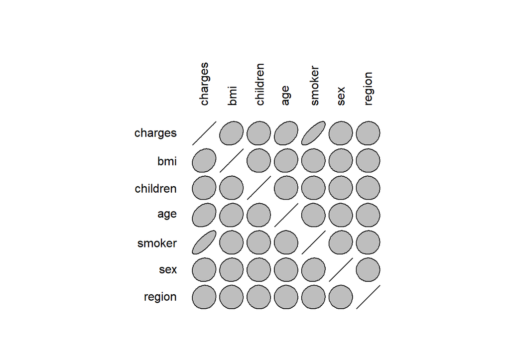

Dal grafico sopra possiamo osservare che, considerando *charges* come variabile risposta, si osserva una correlazione più notevole con le seguenti variabili:

- *bmi* con valore di correlazione 0.20;
- *age* con valore di correlazione 0.30;
- *smoker* con valore di correlazione 0.79.

# B.

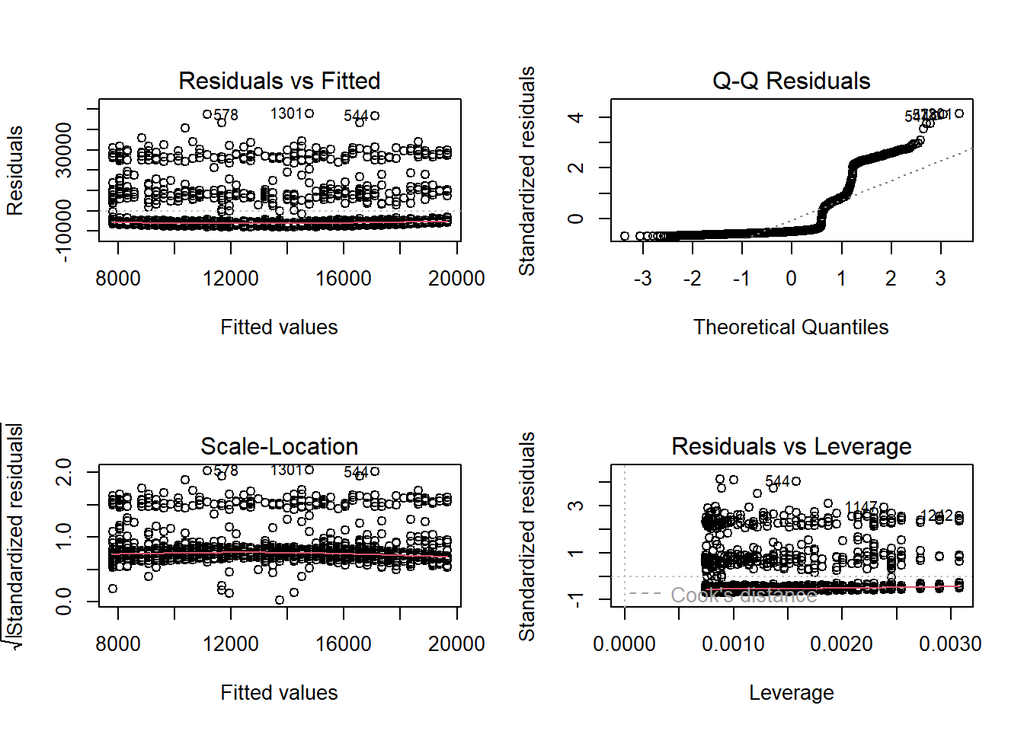

```
##
## Call:
## lm(formula = charges ~ age, data = insurance)
##
## Residuals:
##    Min     1Q Median     3Q    Max
##  -8059  -6671  -5939   5440  47829
##
## Coefficients:
##             Estimate Std. Error t value Pr(>|t|)
## (Intercept)   3165.9      937.1   3.378 0.000751 ***
## age            257.7       22.5  11.453  < 2e-16 ***
## ---
## Signif. codes:  0 '***' 0.001 '**' 0.01 '*' 0.05 '.' 0.1 ' ' 1
##
## Residual standard error: 11560 on 1336 degrees of freedom
## Multiple R-squared:  0.08941,    Adjusted R-squared:  0.08872
## F-statistic: 131.2 on 1 and 1336 DF,  p-value: < 2.2e-16
```

Dal *summary* del modello si nota che l’intercetta ha valore elevato. Da questo deduciamo che già a 18 anni (minima età presente nel dataset) ci sono spese mediche considerevoli: 7804.892 dal modello. Questo dato non si discosta troppo dalla media: 7086.218.

Tale valore per i 18enni fumatori è in media 25473.73, mentre per i non fumatori 3215.162. Questo fa pensare a un’elevata varianza.

Si nota però un valore basso di $R^2$ (0.08872). Quindi questo modello non spiega molto bene i nostri dati. Il motivo è probabilmente che è stato presa in considerazione una sola variabile esplicativa, ma avevamo notato prima che ci sono altre due variabili correlate a *charges*.

Dal *grafico* dei residui si osserva linearità, possibile omoschedasticità, ma si nota che i residui non si distribuiscono lungo la normale.

# C.

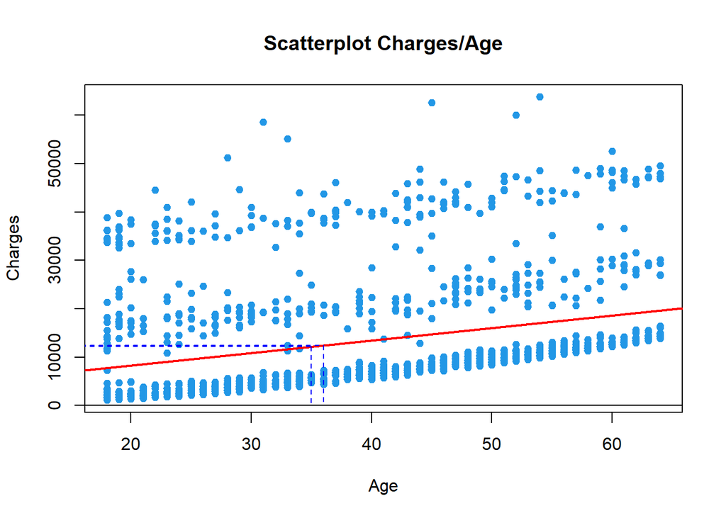

# D.

```
##
## Call:
## lm(formula = charges ~ age + smoker, data = insurance)
##
## Residuals:
##      Min       1Q   Median       3Q      Max
## -16088.1  -2046.8  -1336.4   -212.7  28760.0
##
## Coefficients:
##             Estimate Std. Error t value Pr(>|t|)
## (Intercept) -2391.63     528.30  -4.527 6.52e-06 ***
## age           274.87      12.46  22.069  < 2e-16 ***
## smokeryes   23855.30     433.49  55.031  < 2e-16 ***
## ---
## Signif. codes:  0 '***' 0.001 '**' 0.01 '*' 0.05 '.' 0.1 ' ' 1
##
## Residual standard error: 6397 on 1335 degrees of freedom
## Multiple R-squared:  0.7214, Adjusted R-squared:  0.721
## F-statistic:  1728 on 2 and 1335 DF,  p-value: < 2.2e-16
```

```
##
## Call:
## lm(formula = charges ~ age * smoker, data = insurance)
##
## Residuals:
##      Min       1Q   Median       3Q      Max
## -16072.5  -2043.0  -1348.7   -258.9  28814.6
##
## Coefficients:
##               Estimate Std. Error t value Pr(>|t|)
## (Intercept)   -2091.42     582.57  -3.590 0.000343 ***
## age             267.25      13.93  19.187  < 2e-16 ***
## smokeryes     22385.55    1278.73  17.506  < 2e-16 ***
## age:smokeryes    37.99      31.09   1.222 0.222037
## ---
## Signif. codes:  0 '***' 0.001 '**' 0.01 '*' 0.05 '.' 0.1 ' ' 1
##
## Residual standard error: 6396 on 1334 degrees of freedom
## Multiple R-squared:  0.7217, Adjusted R-squared:  0.7211
## F-statistic:  1153 on 3 and 1334 DF,  p-value: < 2.2e-16
```

```
##                    df      AIC
## linear_fit          3 28835.95
## linear_fit_smoker   4 27253.32
## linear_fit_smoker2  5 27253.83
```

Si nota che il coefficiente quando si considera l’interazione tra age è smoker non è significativo, quindi può essere escluso dal modello. Anche la differenza tra i valori dei rispettivi $R^2$ non è significativa.

Dalla tabella degli AIC notiamo che il modello migliore è *linear_fit_smoker*, anche se non in modo significativo.

# E.

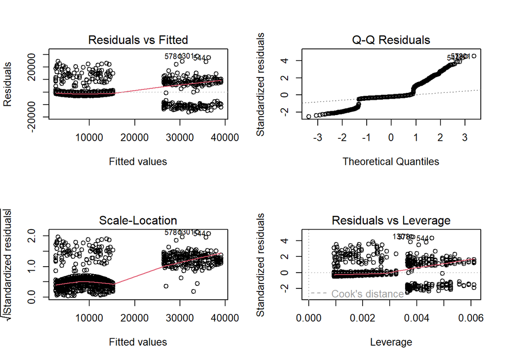

```
##
## Call:
## lm(formula = charges ~ age + smoker, data = insurance)
##
## Residuals:
##      Min       1Q   Median       3Q      Max
## -16088.1  -2046.8  -1336.4   -212.7  28760.0
##
## Coefficients:
##             Estimate Std. Error t value Pr(>|t|)
## (Intercept) -2391.63     528.30  -4.527 6.52e-06 ***
## age           274.87      12.46  22.069  < 2e-16 ***
## smokeryes   23855.30     433.49  55.031  < 2e-16 ***
## ---
## Signif. codes:  0 '***' 0.001 '**' 0.01 '*' 0.05 '.' 0.1 ' ' 1
##
## Residual standard error: 6397 on 1335 degrees of freedom
## Multiple R-squared:  0.7214, Adjusted R-squared:  0.721
## F-statistic:  1728 on 2 and 1335 DF,  p-value: < 2.2e-16
```

A differenza del modello *linear_fit*, qui notiamo un valore di $R^2$ molto migliore. Infatti, questo rappresenta il 72% circa dei dati

Persiste il problema della distribuzione dei residui lungo una distribuzione normale, ma questa volta sono solo i valori sulle code a discostarsi dalla gaussiana.

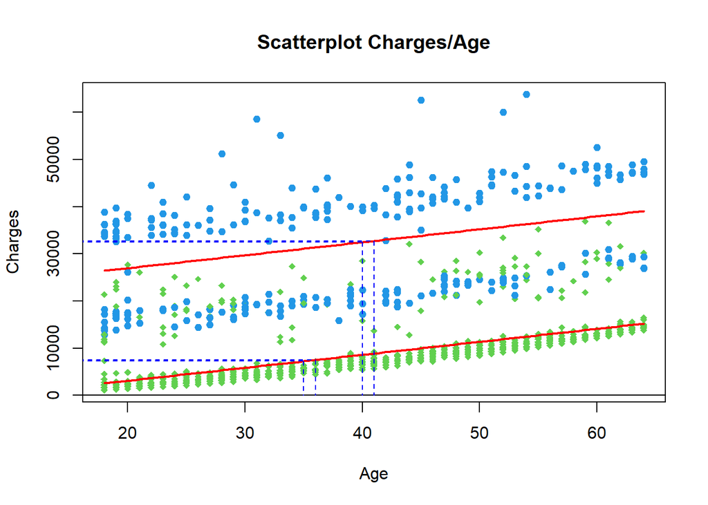

# F.

```r
predict(linear_fit_smoker, data.frame(age = 40, smoker = "yes"))
```

```
##        1
## 32458.53
```

```r
predict(linear_fit_smoker, data.frame(age = 40, smoker = "no"))
```

```
##        1
## 8603.221
```